# Hard Work 12

```r
library(mosaic)
library(car)
library(plotly)
library(reshape2)
library(scatterplot3d)
library(tidyverse)
```

## Instructions

1. Study Chapter 14 – “Logistic Regression, Poisson Regression, and Generalized Linear Models”
2. Attempt and submit at least {50} Hard Work Points by Saturday at 11:59 PM.  
   Over {66} gets you {+1} Final Exam Point.  
   Over {72} gets you {+2} Final Exam Points.

## Reading Points {42} Possible

### Section 14.1 {3}{ A=3 | E=2 }

### Section 14.2 {3}{ A=3 | E=2 }

### Section 14.3 {3}{ A=3 | E=2 }

### Section 14.4 {3}{ A=3 | E=2 }

### Section 14.5 {3}{ A=3 | E=2 }

### Section 14.6 {3}{ A=3 | E=2 }

### Section 14.7 {3}{ A=3 | E=2 }

### Section 14.8 {3}{ A=0 | E=0 }

### Section 14.9 {3}{ A=0 | E=0 }

### Section 14.10 {3}{ A=0 | E=0 }

### Section 14.11 {3}{ A=0 | E=0 }

### Section 14.12 {3}{ A=0 | E=0 }

### Section 14.13 {3}{ A=3 | E=2 }

### Section 14.14 {3}{ A=0 | E=0 }

## Theory Points {6} Possible

### Problem {14.1} {3}{ A=3 | E=3 }

The Benoulli Distribution rises just two possibilities “success” or “failure”. P denotes the probability of success and of failure(1-p). p(0)= (1-p) and p(1)=p.

### Problem {14.3} {3}{ A=3 | E=3 }

This would not be a great time to use logisitc regression. We want the response variable to work more on an S-Shape.

## Application Points {20} Possible

### Problem {14.7} {5}{ A=5 | E=5 }

```r
p14.7 <- read.table("http://users.stat.ufl.edu/~rrandles/sta4210/Rclassnotes/data/textdatasets/KutnerData/Chapter%2014%20Data%20Sets/CH14PR07.txt", header = FALSE)
colnames(p14.7) <- c("Y","X")
```

A

```r
p14.7model <- glm(Y ~ X, data = p14.7, family = binomial)
summary(p14.7model)
```

```
##
## Call:
## glm(formula = Y ~ X, family = binomial, data = p14.7)
##
## Deviance Residuals:
##     Min       1Q   Median       3Q      Max
## -1.7651  -1.0012   0.6502   0.9828   1.6455
##
## Coefficients:
##             Estimate Std. Error z value Pr(>|z|)
## (Intercept) -4.80751    2.65576  -1.810   0.0703 .
## X            0.12508    0.06676   1.874   0.0610 .
## ---
## Signif. codes:  0 '***' 0.001 '**' 0.01 '*' 0.05 '.' 0.1 ' ' 1
##
## (Dispersion parameter for binomial family taken to be 1)
##
##     Null deviance: 41.455  on 29  degrees of freedom
## Residual deviance: 37.465  on 28  degrees of freedom
## AIC: 41.465
##
## Number of Fisher Scoring iterations: 4
```

-0.6000 0.02857
$$\hat{\pi_i} = \frac{e^{-4.80751 + 0.125 X_i}}{1+e6{-4.810751 + 0.125 X_I}}$$
B

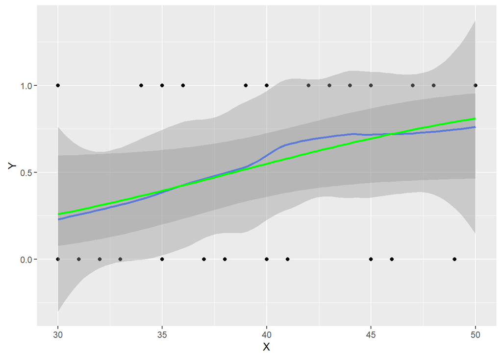

```r
p14.7 %>%
  ggplot(aes(x = X, y = Y))+
  geom_point()+
  geom_smooth()+
  stat_smooth(method = "glm", method.args = list(family= "binomial"), col = "green")
```

C

```r
exp(0.12508)
```

```
## [1] 1.133239
```

1.133239 Every increase in X by 1 you ODDS of leaving increase your chances by 13%. D

```r
predict(p14.7model, data.frame(X = 40, type = "response"))
```

```
##         1
## 0.1956164
```

E

```r
y <- log(0.75/(0.25))
x <- (y + 4.81 / (0.125))
```

It has to increase by 39.58 Dolllars for 75% to cancel their membership.

### Problem {14.9} {5}{ A=5 | E=5 }

```r
p14.9 <- read.table("http://users.stat.ufl.edu/~rrandles/sta4210/Rclassnotes/data/textdatasets/KutnerData/Chapter%2014%20Data%20Sets/CH14PR09.txt", header = FALSE)
colnames(p14.9) <- c("Y","X")
```

A

```r
p14.9model <- glm(Y ~ X, data = p14.9, family = binomial)
summary(p14.9model)
```

```
##
## Call:
## glm(formula = Y ~ X, family = binomial, data = p14.9)
##
## Deviance Residuals:
##     Min       1Q   Median       3Q      Max
## -1.7845  -0.8350   0.5065   0.8371   1.7145
##
## Coefficients:
##               Estimate Std. Error z value Pr(>|z|)
## (Intercept) -10.308925   4.376997  -2.355   0.0185 *
## X             0.018920   0.007877   2.402   0.0163 *
## ---
## Signif. codes:  0 '***' 0.001 '**' 0.01 '*' 0.05 '.' 0.1 ' ' 1
##
## (Dispersion parameter for binomial family taken to be 1)
##
##     Null deviance: 37.393  on 26  degrees of freedom
## Residual deviance: 29.242  on 25  degrees of freedom
## AIC: 33.242
##
## Number of Fisher Scoring iterations: 4
```

-0.6000 0.02857
$$\hat{\pi_i} = \frac{e^{-10.308925 + 0.018920 X_i}}{1+e{-10.308925 + 0.018920 X_I}}$$
B

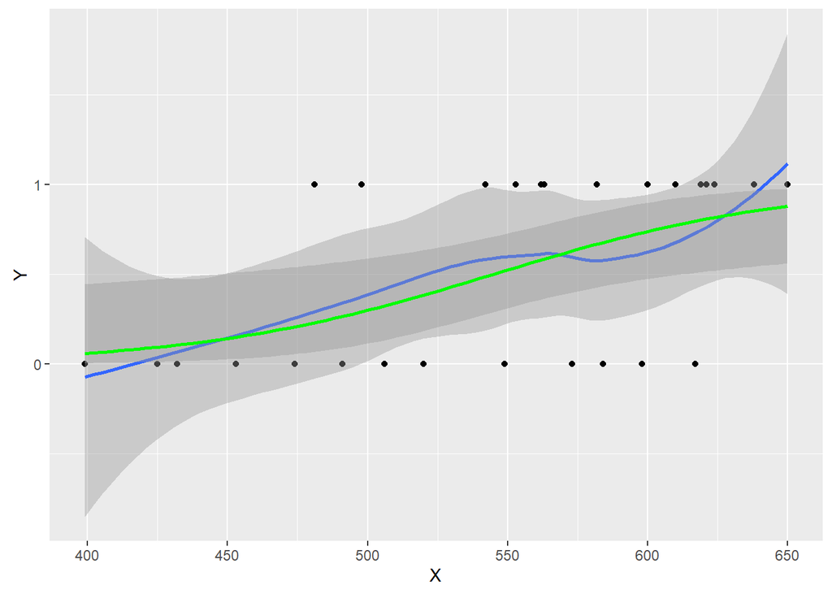

```r
p14.9 %>%
  ggplot(aes(x = X, y = Y))+
  geom_point()+
  geom_smooth()+
  stat_smooth(method = "glm", method.args = list(family= "binomial"), col = "green")
```

C

```r
exp(0.02857)
```

```
## [1] 1.028982
```

```r
predict(p14.9model, data.frame(X = 550, type = "response"))
```

```
##          1
## 0.09698098
```

```r
y <- log(0.70/(0.30))
x <- (y + 10.308925 / (0.018920))
print(x)
```

```
## [1] 545.7165
```

The expected test score of 545.7165.

### Problem {14.13} {5}{ A=5 | E=5 }

```r
p14.13 <- read.table("http://users.stat.ufl.edu/~rrandles/sta4210/Rclassnotes/data/textdatasets/KutnerData/Chapter%2014%20Data%20Sets/CH14PR13.txt", header = FALSE)
colnames(p14.13) <- c("Y","X1","X2")
```

A

```r
p14.13model <- glm(Y ~ X1 + X2, data = p14.13, family = binomial)
summary(p14.13model)
```

```
##
## Call:
## glm(formula = Y ~ X1 + X2, family = binomial, data = p14.13)
##
## Deviance Residuals:
##     Min       1Q   Median       3Q      Max
## -1.6189  -0.8949  -0.5880   0.9653   2.0846
##
## Coefficients:
##             Estimate Std. Error z value Pr(>|z|)
## (Intercept) -4.73931    2.10195  -2.255   0.0242 *
## X1           0.06773    0.02806   2.414   0.0158 *
## X2           0.59863    0.39007   1.535   0.1249
## ---
## Signif. codes:  0 '***' 0.001 '**' 0.01 '*' 0.05 '.' 0.1 ' ' 1
##
## (Dispersion parameter for binomial family taken to be 1)
##
##     Null deviance: 44.987  on 32  degrees of freedom
## Residual deviance: 36.690  on 30  degrees of freedom
## AIC: 42.69
##
## Number of Fisher Scoring iterations: 4
```

$$\hat{\pi_i} = \frac{e^{-4.73931 + 0.06773 X_\text{i1} + 0.59863 X_\text{i2}}} {1+e6{-4.73931 + 0.06773 X_\text{i1}}+ 0.59863 X_\text{i2}}$$
B

```r
exp(0.06773)
```

```
## [1] 1.070076
```

```r
exp(0.59863)
```

```
## [1] 1.819624
```

C

```r
predict(p14.13model, data.frame(X1 = 50000, X2 = 3), type = "response")
```

```
## 1
## 1
```

### Problem {14.14} {5}{ A=5 | E=5 }

```r
p14.14 <- read.table("http://users.stat.ufl.edu/~rrandles/sta4210/Rclassnotes/data/textdatasets/KutnerData/Chapter%2014%20Data%20Sets/CH14PR14.txt", header = FALSE)
colnames(p14.14) <- c("Y","X1","X2","X3")
```

A

```r
p14.14model <- glm(Y ~ X1 + X2 + X3, data = p14.14, family = binomial)
summary(p14.14model)
```

```
##
## Call:
## glm(formula = Y ~ X1 + X2 + X3, family = binomial, data = p14.14)
##
## Deviance Residuals:
##     Min       1Q   Median       3Q      Max
## -1.4037  -0.5637  -0.3352  -0.1542   2.9394
##
## Coefficients:
##             Estimate Std. Error z value Pr(>|z|)
## (Intercept) -1.17716    2.98242  -0.395  0.69307
## X1           0.07279    0.03038   2.396  0.01658 *
## X2          -0.09899    0.03348  -2.957  0.00311 **
## X3           0.43397    0.52179   0.832  0.40558
## ---
## Signif. codes:  0 '***' 0.001 '**' 0.01 '*' 0.05 '.' 0.1 ' ' 1
##
## (Dispersion parameter for binomial family taken to be 1)
##
##     Null deviance: 134.94  on 158  degrees of freedom
## Residual deviance: 105.09  on 155  degrees of freedom
## AIC: 113.09
##
## Number of Fisher Scoring iterations: 6
```

$$\hat{\pi_i} = \frac{e^{-1.17716 + 0.07279 X_\text{i1} + (-0.09899) X_\text{i2} + 0.43397 X_\text{i3}}} {1+e6{-1.7716 + 0.07279 X_\text{i1}}+ (-0.09899) X_\text{i2} + 0.43397 X_\text{i3}}$$

B

```r
exp(0.07279)
```

```
## [1] 1.075505
```

```r
exp(-0.09899)
```

```
## [1] 0.9057518
```

```r
exp(0.43397)
```

```
## [1] 1.543373
```

X1 is a 7.5 % of increase. X2 is a 10% decrease. X3 is a 54% increase.

C

```r
predict(p14.14model, data.frame(X1= 55, X2 = 60, X3 = 1), type = "response")
```

```
##          1
## 0.06422197
```

The probability of 55 year olds with a health index of 60 to recieive the flu shot is 6.4%.